# Introducción

Mayo, 2015

## Quienes sómos ?

Source Stat Lab es una empresa Ecuatoriana con sede en Quito especializada en fomentar el avance del conocimiento estadístico, la cual presta sus servicios de capacitación en el lenguaje estadístico R para profesionales y estudiantes en todas sus verticales (investigación, docencia, empresas, etc.).

[figure not shown]

Source Stat Lab brinda capacitación, reportería y consultoría estadística/matemática con el uso de herramientas de software libre como: R, RStudio, R Analytic Flow & LaTeX a empresas globales y locales, así como instituciones públicas.

## Qué es el análisis de datos ?

[figure not shown]

## Qué es el análisis de datos ?

El **análisis de datos** es un proceso de inspección, limpieza y transformación de datos con el objetivo de resaltar información útil, lo que sugiere conclusiones, y apoyo a la toma de decisiones.

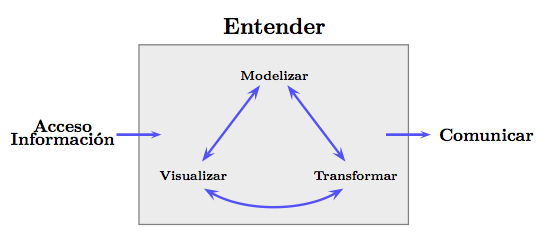

El **análisis de datos** es el proceso por el cual los datos se convierten en conocimiento. *Hadley Wickham*

## Por qué usar un lenguaje de programación ?

- **Programa:** Es una secuencia de instrucciones, escritas para realizar una tarea específica en una computadora.

[figure not shown]

- **Lenguaje de programación:** Es un lenguaje formal diseñado para expresar *procesos* que pueden ser llevados a cabo por máquinas como las computadoras. Está formado por un conjunto de símbolos y reglas sintácticas & semánticas que definen su estructura y el significado de sus elementos y expresiones.

[figure not shown]

## Por qué usar un lenguaje de programación ?

#### Reproducibilidad

[figure not shown]

#### Automatización

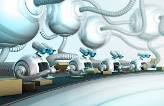

## Por qué usar R ?

[figure not shown]

## Por qué usar R ?

#### Open Source

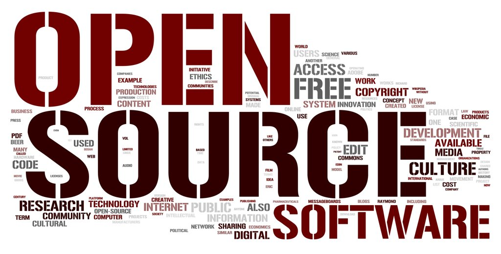

#### Comunidad

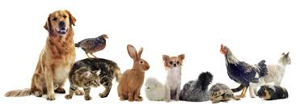

## Por qué usar R ?

#### Multiplataforma

[figure not shown]

#### Estructura personalizable

[figure not shown]

## Por qué usar R ?

#### Conectividad

[figure not shown]

#### Infraestuctura de programación

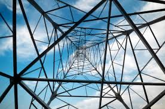

## Ventajas

- Al tratarse de un software libre el costo es nulo.
- Se han implementado una gran cantidad de métodos estadísticos desde los más básicos hasta los más avanzados y modernos. Todos los métodos se encuentran organizados en librerías, las cuales se encuentran en constante crecimiento.
- Facilidad para enlazarse con LaTeX y generar reportes dinámicos.
- Amplia bibliografía tanto en internet como en libros publicados por prestigiosas editoriales como: Springer, Wiley, O'Reilly, Chapman & Hall/CRC, etc.
- Fácil visualización e interpretación de los algoritmos implementados en R con lo cual el usuario puede conocer exactamente lo que el ordenador ejecuta.

## Desventajas

- R como tal no dispone de una interfaz amigable, las tareas se llevan a cabo a través de líneas de comando lo cual puede resultar difícil para el usuario.
- Al ser un programa libre carece de un departamento de atención al cliente al cual se pueda recurrir en caso de que se reporte un inconveniente.
- R no es particularmente un lenguaje de programación rápido, si a eso sumamos que muchos usuarios escriben pobremente su código obtenemos como resultado un funcionamiento lento.

[figure not shown]

## Historia

- R inicia como un experimento para utilizar métodos de Lisp en la construcción de un pequeño banco de pruebas que sirvan para evaluar posibles construcciones de entornos estadísticos.
- Ross Ihaka inicia el proyecto R tras haber obtenido acceso a cierta información importante sobre el lenguaje S, misma que fue publicada por John Chambers y Rick Becker.
- Tiempo más tarde, Ross Ihaka \(\&\) Robert Gentleman llegan a ser colegas en la Universidad de Auckland, como profesores del Departamento de Estadística ven la necesidad de mejorar un ambiente del laboratorio de computación e inician su trabajo con la visión de crear un lenguaje similar al S pero con más funcionalidades.

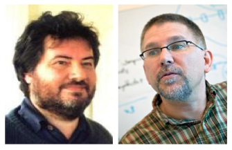

## Historia

- El desarrollo de R como tal inició en el año de 1991, el progreso fue bastante bueno por lo que para Agosto de 1993 decidieron colocar algunas copias binarias de R en Statlib.
- De manera sorpresiva un gran número de personas ofrecieron su retroalimentación sobre la versión que habían liberado, entre ellos el más persistente fue su amigo Martin Machler que los animó a liberar el código fuente de manera que R se distribuya bajo licencia GNU General Public License, por lo cual en Junio de 1995 aparece la primera versión libre.
- R creció rapidamente al punto que para Marzo de 1996 fue necesario crear la propia lista de noticias y un año más tarde se tuvo que reemplazar por listas específicas: R-announce, R-help & R-devel.
- Para a mediados de 1997 se estableció el **R Core Group** o **R Core Team**, un grupo de desarrolladores talentosos y experimentados con permisos para manipular el código fuente de R.
- Para Febrero del año 2000 aparece la versión 1.0.0. Desde entonces el programa se distribuye gratuitamente a través del repositorio *Comprehensive R Archive Network* **CRAN** en http://www.r-project.org.

## CRAN

[figure not shown]

- Lugar desde el cual se obtiene el programa o cualquier paquete que se desee instalar, y con la finalidad de evitar el colapso del **mundo estadístico** no se tiene una única ubicación al que todo mundo tiene acceso.
- CRAN se *refleja* en diferentes lugares de todo el mundo de esta manera como residente en Ecuador, podría acceder a una ubicación. (*ESPOL*).
- La filosofía básica es elegir un repositorio que se encuentre geográficamente cercano al usuario.

## Usuarios R en el mundo

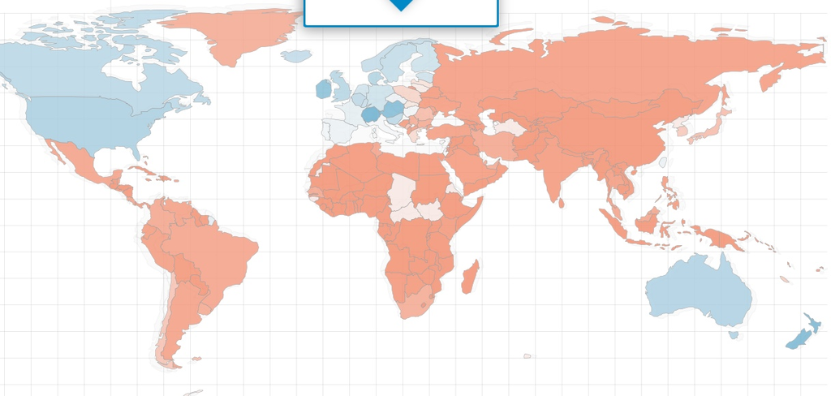

- Suiza
- Nueva Zelanda (Lugar de nacimiento del R)
- Austria (Hogar de la R Foundation)
- Ireland
- United States

## Usuarios de R en Ecuador

[figure not shown]

- Sociedad Ecuatoriana de Estadística
- R Users Group Ecuador
- Use-R.ec